# Proof of Concept for Analyzing the CFR as a Network

Will Wheeler https://willwheels.rbind.io/ (U.S. EPA)  
2020-08-04

Computers make reading things better. This could help us better understand EPA’s bit of the Code of Federal Regulations, something we want to know more about.

Existing studies of the CFR have helped a lot, but we think we can do better. Existing work has focused on the growth and complexity of the CFR in the US, other studies have looked and equivalent documents in France and England. These studies have benefited by treating their corpuses as networks, recognizing that regulatory codes consist of densely incorrection sections that cite each other.

Initially we study only citations from one part of Title 40 to another, specifically those which are of the form “‘any number’ CFR Part ‘any number’” which is the simplest citation format in the CFR. This likely oversimplifies the resulting network but is also simple enough to demonstrate our approach.

The following graphs show fairly substantial increases in the use of Incorporations by Reference, uses of the “CFR” (which we assume to mean a reference to another Part of the CFR), and the sheer number of words in Title 40.

(Please note that the 2009 data seems to be somewhat amiss.)

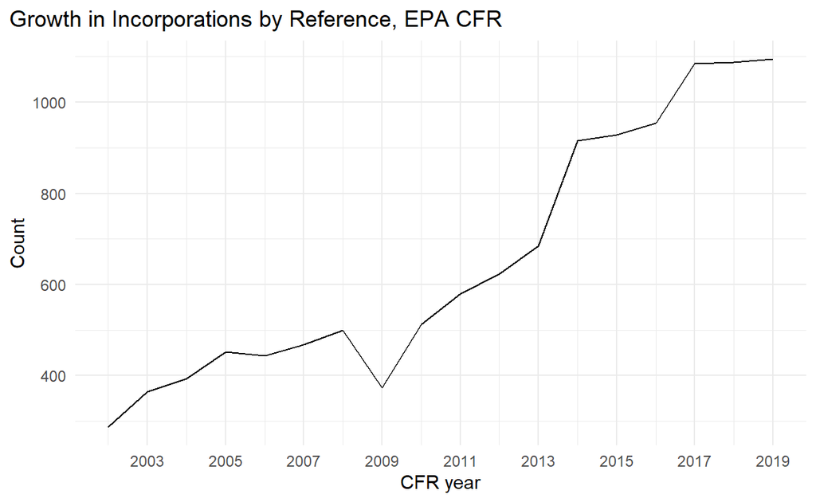

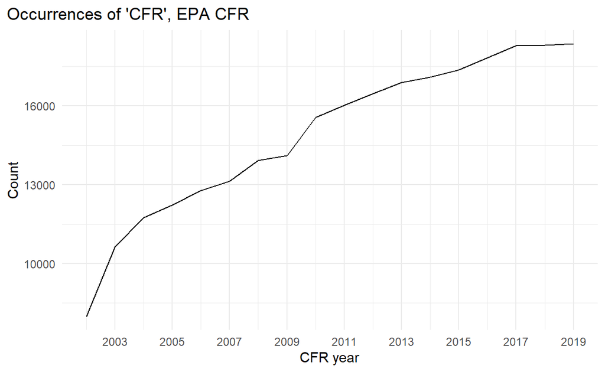

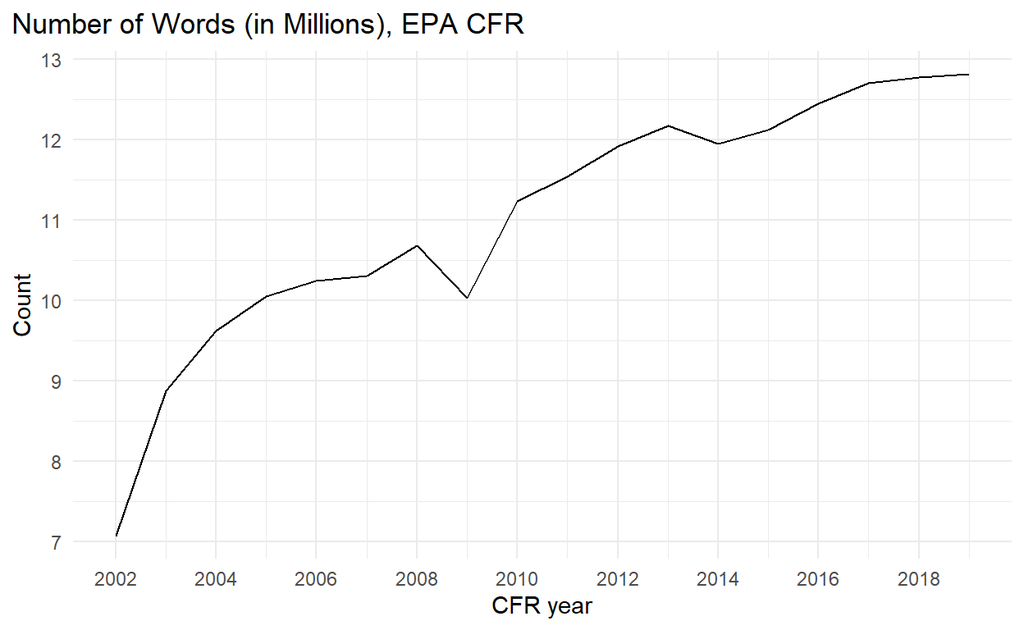